# Downloads_Prudhviii

### Project description:

The purpose of this project is to analyze telco churn data to gain insights into customer behavior and identify factors that contribute to churn. The goal is to help businesses make data-driven decisions, improve customer retention, and reduce customer churn. By analyzing customer demographics, behavior, and sales data, this project will help companies understand patterns and trends that help companies understand why customers churn and factors that can be addressed to improve customer retention. intended to identify. The ultimate goal of this project is to provide businesses with actionable insights that help them make data-driven decisions and improve customer satisfaction.

### Dataset:

A telco Customer churn data is a collection of customer data for a telecommunications company. Records include customer demographics, account information, service usage, and information about whether a customer has terminated (that is, terminated service with the company). The dataset contains 21 columns and his 7,043 rows, each row representing a unique customer. Columns contain information such as customer ID, gender, age, account term, contract type, payment method, service usage, and total charges. This dataset is commonly used in data analytics and machine learning projects to understand customer behavior and identify factors that contribute to customer churn.

### Steps Followed:

1) First i created the tables in the database. These tables are used to store customer data for telecommunications companies. The customer table contains information about the customer's gender, age, and whether they have a partner or dependents. The Services table contains information about services used by customers. Telephone Services, Internet Services, and Streaming Services. The Contracts table contains information about customer contract types, paperless billing statuses, and payment methods. The Accounts table contains information about customer accounts. His tenure, monthly fees, total fees, and whether he terminated. Finally, the Demographics table contains information about the customer's gender, age, and other demographic information. These tables form the basis for storing and organizing customer data that can be used for analysis and decision-making purposes.

2) I read the data in Jupyter notebook and checked for any missing values and checked the datatypes for the columns in the data. By using the replace() function and replacing empty spaces with 'NaN' values from the numpy library, the missing values are explicitly represented in the dataframe, making it easier to identify and handle them.

3) Now that the df has no missing values or any infinite values i went ahead to insert the data into the database using 'mysql.connector'.

4) I used for loop to iterate over each row of the dataframe. For each row, the customerID, gender, SeniorCitizen, Partner, and Dependents column values are retrieved and assigned to value variables. These values are inserted into the appropriate columns of the Customers table using the SQL INSERT statement.

- Execute the SQL statement using the mycursor.execute() function, passing the value variable as an argument to insert the data into the table. This process is repeated for each row in the dataframe, effectively inserting all the data from the Customers dataframe into the Customers table in the MySQL database. I followed the same step for rest of the tables to insert data.

5) Finally i wrote some queries to find out some important data from the dataset

- Examples: Query to find out Total revenue generated by customers who have churned and Total revenue generated by customers who have not churned.
- Query to find the customers who have a monthly charge greater than 100 and are on a month-to-month contract:

```python
import pandas as pd

# Load CSV file into a Pandas dataframe with only 20000 rows
df = pd.read_csv("customer_churn.csv", nrows=20000)


# Check for missing values in the dataframe
print(df.isnull().sum())
```

```
customerID          0
gender              0
SeniorCitizen       0
Partner             0
Dependents          0
tenure              0
PhoneService        0
MultipleLines       0
InternetService     0
OnlineSecurity      0
OnlineBackup        0
DeviceProtection    0
TechSupport         0
StreamingTV         0
StreamingMovies     0
Contract            0
PaperlessBilling    0
PaymentMethod       0
MonthlyCharges      0
TotalCharges        0
Churn               0
dtype: int64
```

```python
#print(df.dtypes)
import numpy as np

df['TotalCharges'] = df['TotalCharges'].replace(' ', np.nan)
```

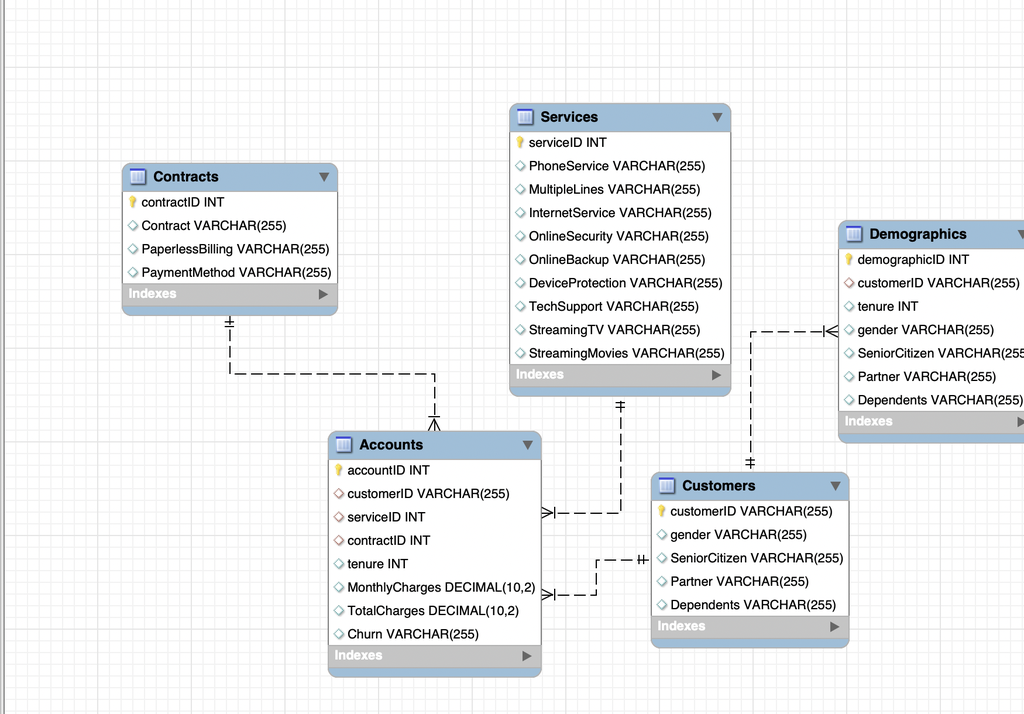

```python
from IPython.display import Image
Image(filename='C:\Users\prudh\Downloads\customer_churn.png')
```

```python
import pandas as pd
import mysql.connector



# Connect to the MySQL database
mydb = mysql.connector.connect(
  host="127.0.0.1",
  user="prudhvi110",
  password="prudhvi819",
  database="churn"
)

# Create a cursor to execute SQL queries
mycursor = mydb.cursor()

# Insert data into the Customers table
for index, row in df.iterrows():
    sql = "INSERT INTO Customers (customerID, gender, SeniorCitizen, Partner, Dependents) VALUES (%s, %s, %s, %s, %s)"
    values = (row['customerID'], row['gender'], row['SeniorCitizen'], row['Partner'], row['Dependents'])
    mycursor.execute(sql, values)

# Insert data into the Services table
for index, row in df.iterrows():
    sql = "INSERT INTO Services (PhoneService, MultipleLines, InternetService, OnlineSecurity, OnlineBackup, DeviceProtection, TechSupport, StreamingTV, StreamingMovies) VALUES (%s, %s, %s, %s, %s, %s, %s, %s, %s)"
    values = (row['PhoneService'], row['MultipleLines'], row['InternetService'], row['OnlineSecurity'], row['OnlineBackup'], row['DeviceProtection'], row['TechSupport'], row['StreamingTV'], row['StreamingMovies'])
    mycursor.execute(sql, values)

# Insert data into the Contracts table
for index, row in df.iterrows():
    sql = "INSERT INTO Contracts (Contract, PaperlessBilling, PaymentMethod) VALUES (%s, %s, %s)"
    values = (row['Contract'], row['PaperlessBilling'], row['PaymentMethod'])
    mycursor.execute(sql, values)

# Insert data into the Accounts table
for index, row in df.iterrows():
    sql = "INSERT INTO Accounts (customerID, serviceID, contractID, tenure, MonthlyCharges, TotalCharges, Churn) VALUES (%s, %s, %s, %s, %s, %s, %s)"
    values = (row['customerID'], 1, 1, row['tenure'], row['MonthlyCharges'], row['TotalCharges'], row['Churn'])
    mycursor.execute(sql, values)

# Insert data into the Demographics table
for index, row in df.iterrows():
    sql = "INSERT INTO Demographics (customerID, tenure, gender, SeniorCitizen, Partner, Dependents) VALUES (%s, %s, %s, %s, %s, %s)"
    values = (row['customerID'], row['tenure'], row['gender'], row['SeniorCitizen'], row['Partner'], row['Dependents'])
    mycursor.execute(sql, values)

# Commit the changes to the database
mydb.commit()

# Close the database connection
mydb.close()
```

### Query to find out the total revenue generated by customers who left and by them who stayed

```python
query = """
    SELECT Accounts.Churn, SUM(Accounts.TotalCharges) AS TotalRevenue
    FROM Accounts
    GROUP BY Accounts.Churn;
"""
mycursor.execute(query)

# fetch the results and print
results = mycursor.fetchall()
churned_revenue = 0
not_churned_revenue = 0
for row in results:
    if row[0] == 'Yes':
        churned_revenue = row[1]
    else:
        not_churned_revenue = row[1]

print(f"Total revenue generated by customers who have churned is {churned_revenue}")
print(f"Total revenue generated by customers who have not churned is {not_churned_revenue}")
```

```
Total revenue generated by customers who have churned is 2862926.90
Total revenue generated by customers who have not churned is 13193241.80
```

### Query to retrieve the total revenue generated by each type of Internet service offered by the company

```python
query = """
    SELECT Services.InternetService, SUM(Accounts.TotalCharges) AS TotalRevenue
    FROM Accounts
    JOIN Services ON Accounts.serviceID = Services.serviceID
    GROUP BY Services.InternetService
"""
mycursor.execute(query)

# Fetch the results and print them
results = mycursor.fetchall()
for row in results:
    print(row)
```

```
('DSL', Decimal('16056168.70'))
```

### Query to show the total revenue generated by each tenure range:

```python
query = """
    SELECT
        CASE
            WHEN tenure <= 12 THEN '0-12 Months'
            WHEN tenure <= 24 THEN '13-24 Months'
            WHEN tenure <= 36 THEN '25-36 Months'
            ELSE '37+ Months'
        END AS TenureRange,
        SUM(Accounts.TotalCharges) AS TotalRevenue
    FROM Accounts
    GROUP BY TenureRange;
"""

mycursor.execute(query)
result = mycursor.fetchall()
for row in result:
    print(row)
```

```
('0-12 Months', Decimal('601651.90'))
('25-36 Months', Decimal('1655845.80'))
('37+ Months', Decimal('12645383.30'))
('13-24 Months', Decimal('1153287.70'))
```

### Query to find the customers who have churned and had a tenure of less than 12 months

```python
query = """
    SELECT customerID, tenure, MonthlyCharges, TotalCharges
    FROM Accounts
    WHERE Churn = 'Yes' AND tenure < 12
"""
mycursor.execute(query)
result = mycursor.fetchall()
for row in result:
    print(row)
```

```
('3668-QPYBK', 2, Decimal('53.85'), Decimal('108.15'))
('9237-HQITU', 2, Decimal('70.70'), Decimal('151.65'))
('9305-CDSKC', 8, Decimal('99.65'), Decimal('820.50'))
('4190-MFLUW', 10, Decimal('55.20'), Decimal('528.35'))
('8779-QRDMV', 1, Decimal('39.65'), Decimal('39.65'))
('1066-JKSGK', 1, Decimal('20.15'), Decimal('20.15'))
('8665-UTDHZ', 1, Decimal('30.20'), Decimal('30.20'))
('6047-YHPVI', 5, Decimal('69.70'), Decimal('316.90'))
('8168-UQWWF', 11, Decimal('97.85'), Decimal('1105.40'))
('7760-OYPDY', 2, Decimal('80.65'), Decimal('144.15'))
('7495-OOKFY', 8, Decimal('80.65'), Decimal('633.30'))
('5698-BQJOH', 9, Decimal('94.40'), Decimal('857.25'))
('5919-TMRGD', 1, Decimal('79.35'), Decimal('79.35'))
('9191-MYQKX', 7, Decimal('75.15'), Decimal('496.90'))
('0278-YXOOG', 5, Decimal('21.05'), Decimal('113.85'))
('5299-RULOA', 10, Decimal('100.25'), Decimal('1064.65'))
('0404-SWRVG', 3, Decimal('74.40'), Decimal('229.55'))
('3091-FYHKI', 1, Decimal('35.45'), Decimal('35.45'))
('2372-HWUHI', 2, Decimal('44.35'), Decimal('81.25'))
('0390-DCFDQ', 1, Decimal('70.45'), Decimal('70.45'))
('4080-OGPJL', 8, Decimal('71.15'), Decimal('563.65'))
('2135-RXIHG', 1, Decimal('45.65'), Decimal('45.65'))
('3874-EQOEP', 7, Decimal('95.00'), Decimal('655.50'))
('3376-BMGFE', 4, Decimal('70.90'), Decimal('273.00'))
('1875-QIVME', 2, Decimal('104.40'), Decimal('242.80'))
('2070-FNEXE', 7, Decimal('76.45'), Decimal('503.60'))
('6317-YPKDH', 1, Decimal('29.95'), Decimal('29.95'))
('9367-WXLCH', 8, Decimal('84.50'), Decimal('662.65'))
('1024-GUALD', 1, Decimal('24.80'), Decimal('24.80'))
('2472-OVKUP', 6, Decimal('91.00'), Decimal('531.00'))
('1285-OKIPP', 1, Decimal('79.90'), Decimal('79.90'))
('7841-TZDMQ', 2, Decimal('46.00'), Decimal('84.50'))
('9408-SSNVZ', 4, Decimal('70.15'), Decimal('268.35'))
('0742-MOABM', 4, Decimal('50.05'), Decimal('179.35'))
('2232-DMLXU', 1, Decimal('55.20'), Decimal('55.20'))
('8937-RDTHP', 1, Decimal('84.60'), Decimal('84.60'))
('1251-KRREG', 2, Decimal('54.40'), Decimal('114.10'))
('0094-OIFMO', 11, Decimal('95.00'), Decimal('1120.30'))
('0322-YINQP', 1, Decimal('48.55'), Decimal('48.55'))
('4629-NRXKX', 2, Decimal('70.40'), Decimal('147.15'))
```

[output cut: 944 more lines]

```
('6502-MJQAE', 1, Decimal('69.60'), Decimal('69.60'))
('7693-LCKZL', 5, Decimal('80.15'), Decimal('385.00'))
('0032-PGELS', 1, Decimal('30.50'), Decimal('30.50'))
('4745-LSPLO', 1, Decimal('20.50'), Decimal('20.50'))
('8083-YTZES', 4, Decimal('74.35'), Decimal('265.35'))
('3585-ISXZP', 8, Decimal('95.65'), Decimal('778.10'))
('2108-XWMPY', 3, Decimal('35.45'), Decimal('106.85'))
('6304-IJFSQ', 3, Decimal('49.90'), Decimal('130.10'))
('1980-KXVPM', 3, Decimal('75.05'), Decimal('256.25'))
('0723-DRCLG', 1, Decimal('74.45'), Decimal('74.45'))
('5482-NUPNA', 4, Decimal('60.40'), Decimal('272.15'))
('1122-JWTJW', 1, Decimal('70.65'), Decimal('70.65'))
('8775-CEBBJ', 9, Decimal('44.20'), Decimal('403.35'))
('6894-LFHLY', 1, Decimal('75.75'), Decimal('75.75'))
('8361-LTMKD', 4, Decimal('74.40'), Decimal('306.60'))
```

### Query to find the customers who have a monthly charge greater than 100 and are on a month-to-month contract:

```python
query = """
    SELECT Customers.customerID, Customers.gender, Customers.SeniorCitizen, Customers.Partner, Customers.Dependents,
           Accounts.tenure, Accounts.MonthlyCharges, Accounts.TotalCharges, Accounts.Churn
    FROM Customers
    JOIN Accounts ON Customers.customerID = Accounts.customerID
    JOIN Contracts ON Accounts.contractID = Contracts.contractID
    WHERE Accounts.MonthlyCharges > 100 AND Contracts.Contract = 'Month-to-month'
"""

mycursor.execute(query)
result = mycursor.fetchall()
for row in result:
    print(row)
```

```
('7892-POOKP', 'Female', '0', 'Yes', 'No', 28, Decimal('104.80'), Decimal('3046.05'), 'Yes')
('8091-TTVAX', 'Male', '0', 'Yes', 'No', 58, Decimal('100.35'), Decimal('5681.10'), 'No')
('0280-XJGEX', 'Male', '0', 'No', 'No', 49, Decimal('103.70'), Decimal('5036.30'), 'Yes')
('5129-JLPIS', 'Male', '0', 'No', 'No', 25, Decimal('105.50'), Decimal('2686.05'), 'No')
('3655-SNQYZ', 'Female', '0', 'Yes', 'Yes', 69, Decimal('113.25'), Decimal('7895.15'), 'No')
('9959-WOFKT', 'Male', '0', 'No', 'Yes', 71, Decimal('106.70'), Decimal('7382.25'), 'No')
('5380-WJKOV', 'Male', '0', 'No', 'No', 34, Decimal('106.35'), Decimal('3549.25'), 'Yes')
('5067-XJQFU', 'Male', '1', 'Yes', 'Yes', 66, Decimal('108.45'), Decimal('7076.35'), 'No')
('5954-BDFSG', 'Female', '0', 'No', 'No', 72, Decimal('107.50'), Decimal('7853.70'), 'No')
('0434-CSFON', 'Female', '0', 'Yes', 'No', 47, Decimal('100.50'), Decimal('4707.10'), 'No')
('1891-QRQSA', 'Male', '1', 'Yes', 'Yes', 64, Decimal('111.60'), Decimal('7099.00'), 'No')
('2673-CXQEU', 'Female', '1', 'No', 'No', 56, Decimal('110.50'), Decimal('6139.50'), 'No')
('9919-YLNNG', 'Female', '0', 'No', 'No', 42, Decimal('103.80'), Decimal('4327.50'), 'No')
('6067-NGCEU', 'Female', '0', 'No', 'No', 65, Decimal('111.05'), Decimal('7107.00'), 'No')
('9848-JQJTX', 'Male', '0', 'No', 'No', 72, Decimal('100.90'), Decimal('7459.05'), 'No')
('3192-NQECA', 'Male', '0', 'Yes', 'No', 68, Decimal('110.00'), Decimal('7611.85'), 'Yes')
('6728-DKUCO', 'Female', '0', 'Yes', 'Yes', 72, Decimal('104.15'), Decimal('7303.05'), 'No')
('5299-RULOA', 'Female', '0', 'Yes', 'Yes', 10, Decimal('100.25'), Decimal('1064.65'), 'Yes')
('1095-WGNGG', 'Female', '0', 'Yes', 'No', 61, Decimal('101.05'), Decimal('5971.25'), 'No')
('1679-JRFBR', 'Female', '0', 'Yes', 'Yes', 70, Decimal('108.15'), Decimal('7930.55'), 'No')
('1875-QIVME', 'Female', '0', 'Yes', 'No', 2, Decimal('104.40'), Decimal('242.80'), 'Yes')
('5947-SGKCL', 'Female', '0', 'Yes', 'Yes', 15, Decimal('105.35'), Decimal('1559.25'), 'No')
('9680-NIAUV', 'Female', '0', 'Yes', 'Yes', 72, Decimal('109.70'), Decimal('8129.30'), 'No')
('6168-YBYNP', 'Male', '0', 'No', 'No', 59, Decimal('111.35'), Decimal('6519.75'), 'No')
('7255-SSFBC', 'Male', '0', 'Yes', 'Yes', 72, Decimal('112.25'), Decimal('8041.65'), 'No')
('9323-HGFWY', 'Female', '0', 'Yes', 'No', 27, Decimal('101.90'), Decimal('2681.15'), 'No')
('3363-DTIVD', 'Male', '0', 'Yes', 'Yes', 71, Decimal('105.55'), Decimal('7405.50'), 'No')
('7825-ECJRF', 'Female', '0', 'No', 'No', 19, Decimal('106.60'), Decimal('1934.45'), 'Yes')
('1347-KTTTA', 'Male', '0', 'Yes', 'No', 64, Decimal('102.45'), Decimal('6654.10'), 'No')
('2651-ZCBXV', 'Male', '0', 'No', 'No', 54, Decimal('108.00'), Decimal('5760.65'), 'No')
('6614-FHDBO', 'Male', '0', 'No', 'No', 72, Decimal('109.20'), Decimal('7878.30'), 'No')
('7017-VFHAY', 'Female', '0', 'Yes', 'Yes', 61, Decimal('115.10'), Decimal('7008.15'), 'No')
('6655-LHBYW', 'Male', '0', 'No', 'No', 50, Decimal('114.35'), Decimal('5791.10'), 'No')
('3606-TWKGI', 'Male', '1', 'No', 'No', 13, Decimal('106.90'), Decimal('1364.30'), 'Yes')
('1950-KSVVJ', 'Female', '0', 'Yes', 'No', 45, Decimal('113.30'), Decimal('5032.25'), 'No')
('3197-ARFOY', 'Female', '1', 'No', 'No', 19, Decimal('105.00'), Decimal('2007.25'), 'No')
('4716-HHKQH', 'Male', '1', 'Yes', 'No', 20, Decimal('107.05'), Decimal('2172.05'), 'No')
('4484-GLZOU', 'Female', '0', 'Yes', 'No', 52, Decimal('105.05'), Decimal('5624.85'), 'Yes')
('6851-WEFYX', 'Male', '1', 'Yes', 'No', 35, Decimal('100.80'), Decimal('3437.50'), 'No')
('3167-SNQPL', 'Male', '1', 'Yes', 'Yes', 38, Decimal('101.15'), Decimal('3741.85'), 'No')
```

[output cut: 847 more lines]

```
('2898-MRKPI', 'Male', '0', 'Yes', 'Yes', 68, Decimal('101.05'), Decimal('6770.50'), 'No')
('2750-BJLSB', 'Female', '0', 'No', 'No', 47, Decimal('103.70'), Decimal('4730.60'), 'No')
('6394-MFYNG', 'Female', '0', 'No', 'No', 48, Decimal('107.40'), Decimal('5121.30'), 'Yes')
('0886-QGENL', 'Female', '1', 'Yes', 'No', 27, Decimal('101.25'), Decimal('2754.45'), 'Yes')
('9547-ITEFG', 'Male', '0', 'Yes', 'Yes', 9, Decimal('102.60'), Decimal('897.75'), 'No')
('6664-FPDAC', 'Female', '1', 'No', 'No', 56, Decimal('111.95'), Decimal('6418.90'), 'Yes')
('5981-ZVXOT', 'Female', '1', 'No', 'No', 35, Decimal('108.35'), Decimal('3726.15'), 'No')
('0218-QNVAS', 'Male', '0', 'Yes', 'Yes', 71, Decimal('100.55'), Decimal('7113.75'), 'No')
('9586-JGQKH', 'Female', '0', 'Yes', 'No', 64, Decimal('105.40'), Decimal('6794.75'), 'No')
('0093-XWZFY', 'Male', '0', 'No', 'No', 40, Decimal('104.50'), Decimal('4036.85'), 'Yes')
('7203-OYKCT', 'Male', '0', 'No', 'No', 72, Decimal('104.95'), Decimal('7544.30'), 'No')
('1035-IPQPU', 'Female', '1', 'Yes', 'No', 63, Decimal('103.50'), Decimal('6479.40'), 'No')
('0639-TSIQW', 'Female', '0', 'No', 'No', 67, Decimal('102.95'), Decimal('6886.25'), 'Yes')
('2234-XADUH', 'Female', '0', 'Yes', 'Yes', 72, Decimal('103.20'), Decimal('7362.90'), 'No')
('3186-AJIEK', 'Male', '0', 'No', 'No', 66, Decimal('105.65'), Decimal('6844.50'), 'No')
```

### Query to find the number of customers by payment method who have a monthly charge less than 50 and churned

```python
query = """
    SELECT Contracts.PaymentMethod, COUNT(Customers.customerID) AS NumberOfCustomers
    FROM Customers
    JOIN Accounts ON Customers.customerID = Accounts.customerID
    JOIN Contracts ON Accounts.contractID = Contracts.contractID
    WHERE Accounts.MonthlyCharges < 50 AND Accounts.Churn = 'Yes'
    GROUP BY Contracts.PaymentMethod;
"""
mycursor.execute(query)

# Fetch the results and print them
results = mycursor.fetchall()
for row in results:
    print("The number of customers who have a monthly charge less than $50 and churned and use {} payment method is {}.".format(row[0], row[1]))
```

```
The number of customers who have a monthly charge less than $50 and churned and use Electronic check payment method is 361.
```

### Query to find out ave tenure of both genders

```python
query = """
    SELECT gender, AVG(tenure)
    FROM Demographics
    GROUP BY gender
"""
mycursor.execute(query)
result = mycursor.fetchall()
for row in result:
    print(f"The average tenure of {row[0]} customers is {row[1]:.2f} months.")
```

```
The average tenure of Female customers is 32.24 months.
The average tenure of Male customers is 32.50 months.
```

### Query to find out the revenue loss if all female customers left to find impact of gender

```python
query = """
    SELECT gender, SUM(TotalCharges) AS TotalRevenue
    FROM Customers
    JOIN Accounts ON Customers.customerID = Accounts.customerID
    GROUP BY gender
"""

mycursor.execute(query)
results = mycursor.fetchall()

for row in results:
    if row[0] == 'Female':
        revenue_loss = row[1]

total_revenue = sum([row[1] for row in results])

percent_loss = revenue_loss / total_revenue * 100
print(f"The revenue loss if all female customers left would be {percent_loss:.2f}% of the total revenue.")
```

```
The revenue loss if all female customers left would be 49.53% of the total revenue.
```

### Query to find the total revenue generated by all customers

```python
query_total_revenue = "SELECT SUM(TotalCharges) FROM Accounts;"
mycursor.execute(query_total_revenue)
total_revenue = mycursor.fetchone()[0]

# Execute the SQL query to find the total revenue generated by churned customers
query_churned_revenue = "SELECT SUM(TotalCharges) FROM Accounts WHERE Churn = 'Yes';"
mycursor.execute(query_churned_revenue)
churned_revenue = mycursor.fetchone()[0]

# Calculate the profit in revenue if the churned customers didn't leave
profit_in_revenue = total_revenue - churned_revenue

# Print the result
print("The profit in revenue if the churned customers didn't leave is: $", profit_in_revenue)
print(row)
```

```
The profit in revenue if the churned customers didn't leave is: $ 13193241.80
('Male', Decimal('8103814.50'))
```

### Performed logistic regression to find the accuracy of the model

```python
import mysql.connector
from sklearn.linear_model import LogisticRegression
from sklearn.metrics import accuracy_score
from sklearn.model_selection import train_test_split
from sklearn.preprocessing import StandardScaler

# Connect to the database
cnx = mysql.connector.connect(user='prudhvi110', password='prudhvi819',
                              host='127.0.0.1',
                              database='churn')
cursor = cnx.cursor()

# Query the database to retrieve the necessary data
query = """
    SELECT Accounts.MonthlyCharges, Accounts.tenure, Accounts.Churn
    FROM Accounts
    JOIN Customers ON Accounts.customerID = Customers.customerID
"""

cursor.execute(query)
data = cursor.fetchall()

# Prepare the data for modeling
X = [[ row[0], row[1]] for row in data]
y = [row[2] for row in data]

# Split the data into training and testing sets
X_train, X_test, y_train, y_test = train_test_split(X, y, test_size=0.3, random_state=0)

# Scale the features
sc = StandardScaler()
X_train = sc.fit_transform(X_train)
X_test = sc.transform(X_test)

# Train a logistic regression model
model = LogisticRegression()
model.fit(X_train, y_train)

# Predict the probability of churn for each customer in the testing set
y_pred = model.predict_proba(X_test)[:, 1]

# Print the accuracy score of the model
print("Accuracy:", accuracy_score(y_test, model.predict(X_test)))

# Close the database connection
cnx.close()
```

```
Accuracy: 0.7893989588263133
```